# act_report

## Report: Act_report

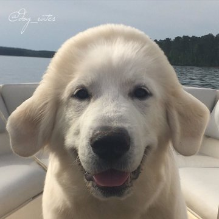

This documentation communicates the insights and displays the visualizations produced from the wrangled data.

### Insights

- What is associated with maximum retweet_count
- What is associated with maximum favorite_count
- What is associated with the maximum rating
- What is the highest confidence score of algorithm 1

Here is the information associated with the first insight.

[figure not shown]

> The name of the dog with the **maximum retweet count (51,790)** is **Stephan**. Stephan stage is not specified. This dog has a **favorite count of 111,909** and belongs to the dog breed of **Chihuahua** predicted by algorithm 1.

Information associated with the second insight.

> There is not much to say here because the same dog, **Stephan**, which had the maximum retweet count has the **maximum favorite count (111,909)**.

**Findings on the third insights. Meet Cassie**

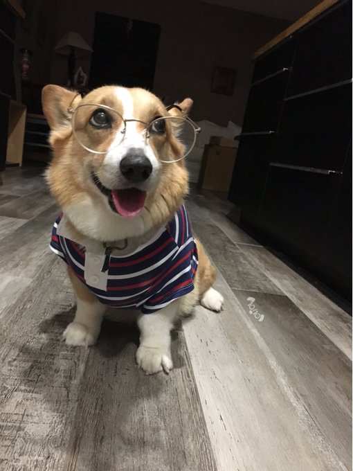

> One of the dog with the **highest rating (14)** is **Cassie**. This dog is in its **doggo stage**. Cassie belongs to the cardigan breed of dogs as predicted by algorithm 2 and have a **retweet count** and **favorite count** of **6,110** and **27,990** respectively.

**The last but not the least insight. Meet Lenox**

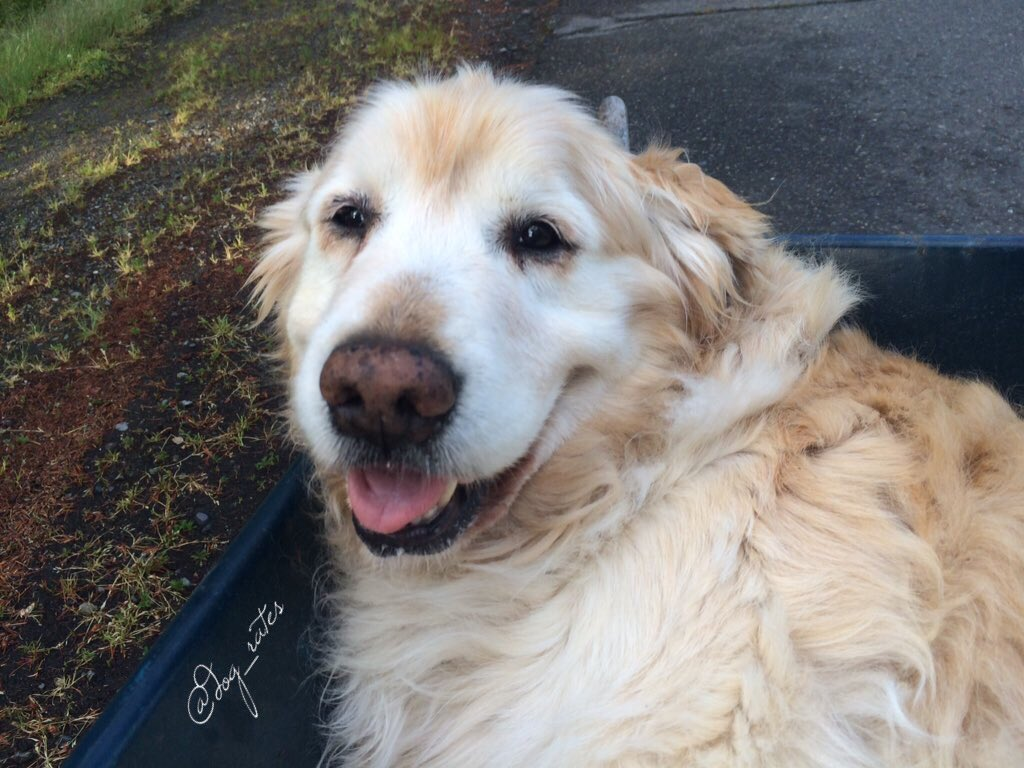

> The **highest confidence score of algorithm 1** is **0.999952**. In its prediction, it was able to identify **Lenox** as a dog belonging to the breed of **Barrow**. Lenox has a rating of **10** and is in its **doggo** stage. Also Lenox has a **retweet count** and **favorite count** of **2,318** and **6,559** respectively.

### Visualizations

**Different Dog stage**

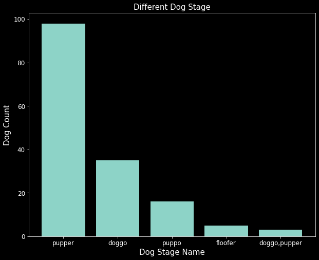

The dog stage was visualized to know which is the most posted. From the chart, we can see that **Pupper** have the highest count. A question came up while looking at the chart, if pupper are the most posted stage of a dog, that means they have the highest retweet count, right? This question led to the next visualization.

[figure not shown]

**Most Retweeted Dog Stage**

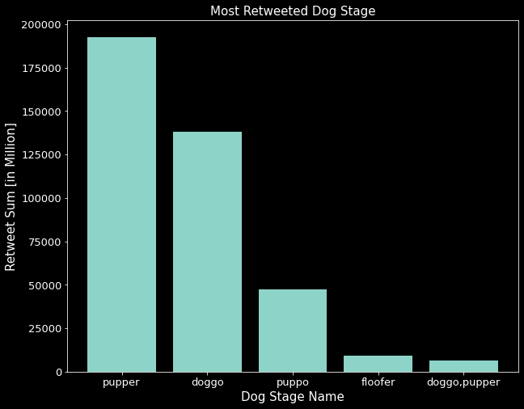

Well, It seems our inference was true. **Pupper** being the most posted dog stage has the highest retweet. Let's look at the most predicted dog breed.

**15 Most Predicted Dog Breed in Algorithm 1**

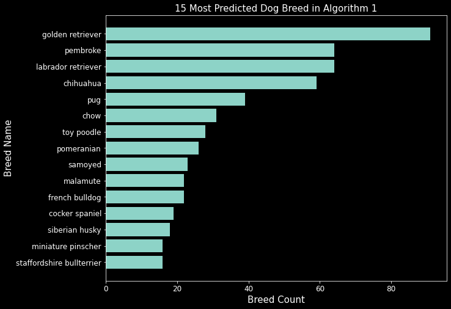

**15 Most Predicted Dog Breed in Algorithm 2**

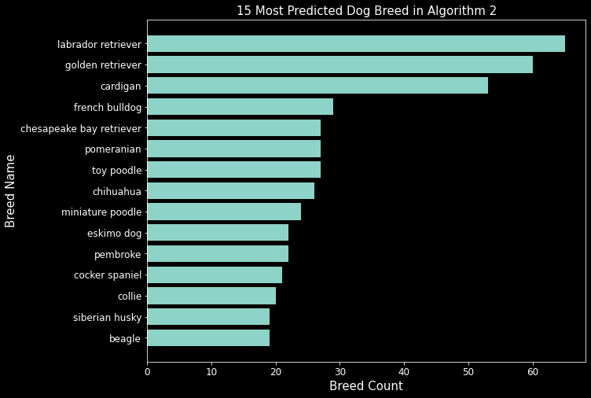

The visualization above shows the top 15 dog breeds pedicted by algorithm 2. **Labrador retriever** is the most predicted dog breed followed by **Golden retriever**.

[figure not shown]

**15 Most Predicted Dog Breed in Algorithm 3**

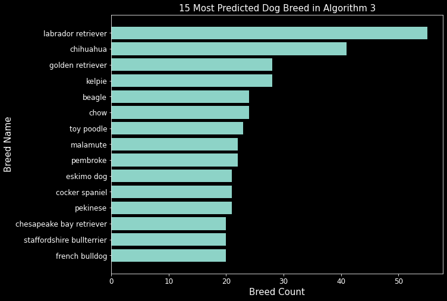

The visualization above shows the top 15 dog breeds predicted by algorithm 3. **Labrador retriever** is the most predicted dog breed followed by **Chihuahua**.

**Relationships:** We will see the relationship between rating, retweet count and favorite count.

**Relationship Between Favorite count and Retweet count**

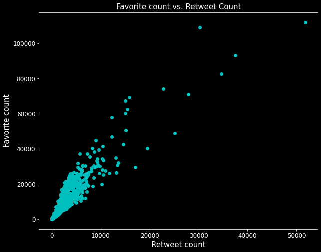

There is a **positive relationship** between the two. Let's look at rating and retweet count.

[figure not shown]

**Relationship Between Rating and Retweet count**

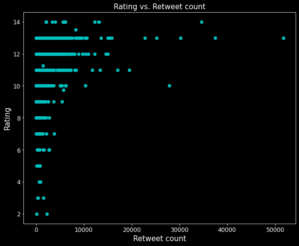

**Relationship Between Rating and Favorite count**

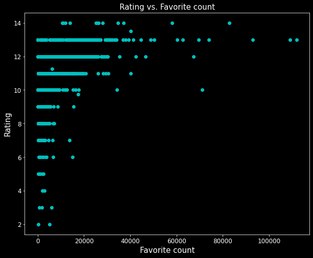

The above plot is similar to the previous. Probably because favorite count has a positive relationship with retweet count. Regardless, the favorite count of dog tweets is also **not dependent on the rating**. The **highest favorite count** falls between the **rating of 10 to 14**

The above are the insights and visualization from the project. It is not limited to this as more can be revealed from the wrangled data.